# Soluzione esercizio 4

Cristiano Varin

Leggiamo i dati:

```r
efficienza <- read.csv("efficienza.csv")
```

Visualizziamo i dati:

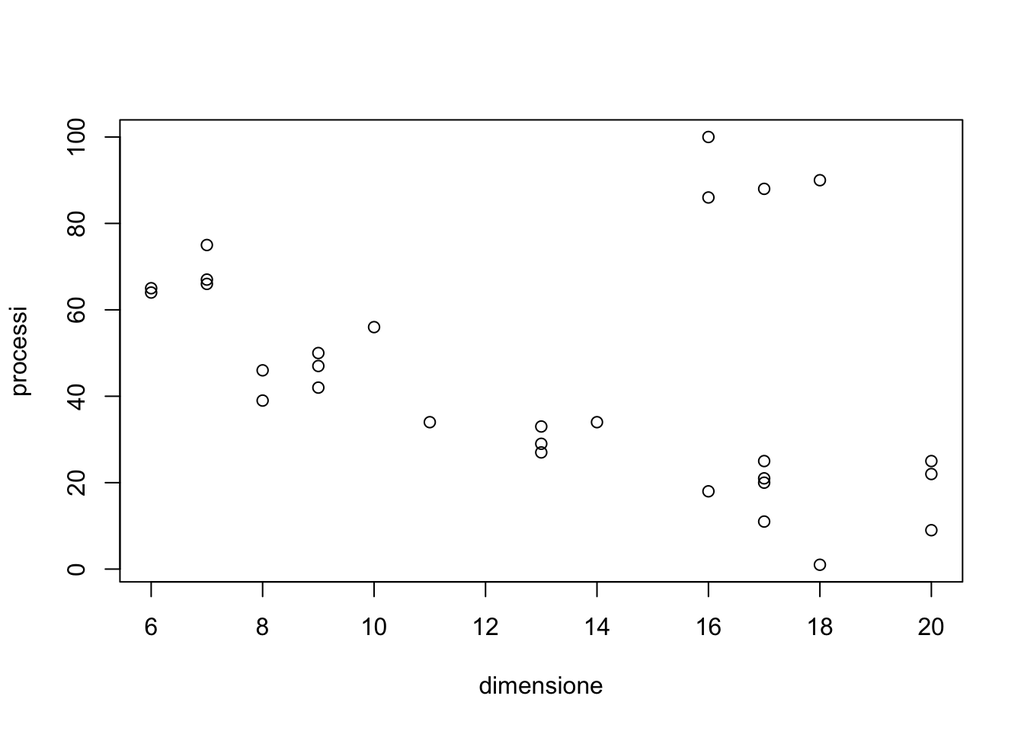

```r
plot(processi ~ dimensione, data = efficienza)
```

Il grafico mostra un andamento decrescente non lineare del numero di processi in funzione della dimensione per la gran parte delle osservazioni a meno di un grappolo di quattro osservazioni con valori del numero di processi elaborati anomalmente grandi.

Le osservazioni anomale sono:

```r
outliers <- which(efficienza$processi > 80)
outliers
```

```
## [1]  6 12 17 18
```

Stimiamo un modello quadratico su tutti i dati:

```r
mod <- lm(processi ~ dimensione + I(dimensione ^ 2), data = efficienza)
summary(mod)
```

```
##
## Call:
## lm(formula = processi ~ dimensione + I(dimensione^2), data = efficienza)
##
## Residuals:
##     Min      1Q  Median      3Q     Max
## -33.340 -15.065  -9.130   5.615  62.129
##
## Coefficients:
##                 Estimate Std. Error t value Pr(>|t|)
## (Intercept)     77.65236   45.39156   1.711    0.099 .
## dimensione      -3.12734    7.76788  -0.403    0.691
## I(dimensione^2)  0.04006    0.29932   0.134    0.895
## ---
## Signif. codes:  0 '***' 0.001 '**' 0.01 '*' 0.05 '.' 0.1 ' ' 1
##
## Residual standard error: 25.74 on 26 degrees of freedom
## Multiple R-squared:  0.1375, Adjusted R-squared:  0.07119
## F-statistic: 2.073 on 2 and 26 DF,  p-value: 0.1461
```

e poi togliendo i dati anomali:

```r
mod2 <- lm(processi ~ dimensione + I(dimensione ^ 2), data = efficienza,
           subset = -outliers)
summary(mod2)
```

```
##
## Call:
## lm(formula = processi ~ dimensione + I(dimensione^2), data = efficienza,
##     subset = -outliers)
##
## Residuals:
##      Min       1Q   Median       3Q      Max
## -16.1198  -4.0948  -0.2255   6.0238  14.0238
##
## Coefficients:
##                  Estimate Std. Error t value Pr(>|t|)
## (Intercept)     121.76706   14.73409   8.264 3.43e-08 ***
## dimensione      -10.51119    2.52539  -4.162 0.000406 ***
## I(dimensione^2)   0.26097    0.09676   2.697 0.013164 *
## ---
## Signif. codes:  0 '***' 0.001 '**' 0.01 '*' 0.05 '.' 0.1 ' ' 1
##
## Residual standard error: 8.124 on 22 degrees of freedom
## Multiple R-squared:  0.852,  Adjusted R-squared:  0.8386
## F-statistic: 63.33 on 2 and 22 DF,  p-value: 7.452e-10
```

Visualizziamo i due modelli stimati:

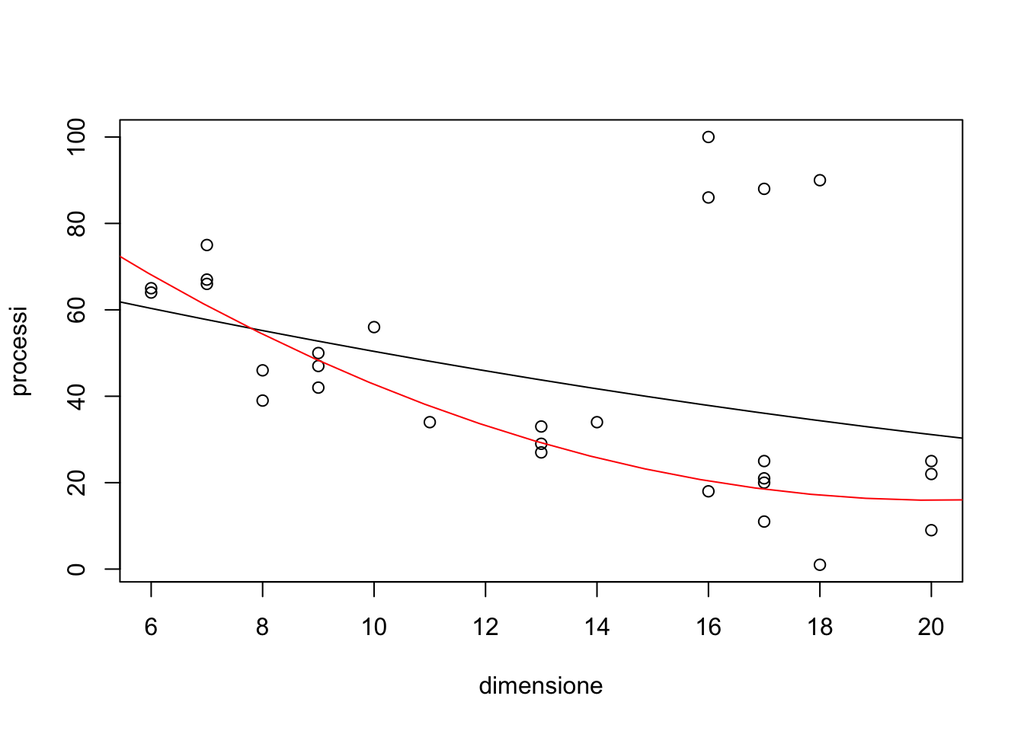

```r
plot(processi ~ dimensione, data = efficienza)
curve(coef(mod)[1] + coef(mod)[2] * x + coef(mod)[3] * x ^ 2, from = min(efficienza$processi), to = max(efficienza$processi), add = TRUE)
curve(coef(mod2)[1] + coef(mod2)[2] * x + coef(mod2)[3] * x ^ 2, from = min(efficienza$processi), to = max(efficienza$processi), add = TRUE, col = "red")
```

Il modello stimato togliendo i quattro outliers è significativamente diverso e si adatta meglio alle rimanenti osservazioni a confermare che i punti anomali andavano rimossi.

Analisi dei residui del modello con gli outliers rimossi:

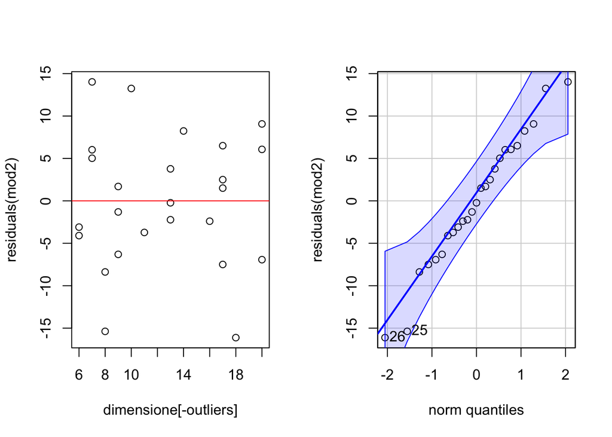

```
## 26 25
## 22 21
```

```r
library(car)
par(mfrow = c(1, 2))
plot(residuals(mod2) ~ dimensione[-outliers], data = efficienza)
abline(h = 0, col = "red")
qqPlot(residuals(mod2))
```

L’analisi dei residui è relativamente adeguata tenendo conto delle poche osservazioni.

Il modello stimato sui dati senza gli outliers:

- spiega l’85% della variabilità del numero di processi elaborati;
- conferma la relazione decrescente non lineare fra numero di processi elaborati e dimensione dei datasets.

Calcoliamo l’intervallo di previsione al 95% per il numero di processi elaborati con un dataset di dimensione 10 Gigabyte:

```r
predict(mod2, newdata = data.frame(dimensione = 10), interval = "prediction")
```

```
##        fit      lwr      upr
## 1 42.75213 25.25709 60.24717
```

Se invece la dimensione fosse pari a 15 Gigabyte allora il numero di processi elaborati previsto dal modello scende a:

```r
predict(mod2, newdata = data.frame(dimensione = 15), interval = "prediction")
```

```
##        fit      lwr      upr
## 1 22.81737 5.162408 40.47234
```